# Мониторинг vs. bus.gov.ru

# Что мы хотим

На **сайте bus.gov.ru** обнаужены отчеты о результатах финансово-хозяйственной деятельности **462 вузов** (отчеты на конец 2018 года).

По данным **Мониторинга** мы знаем о доходах **499** государственных вузов (без филиалов) (так же на конец 2018 года).

Четыре пункта на которые мы посмотрим:

1. проблемы которые есть в отчетах bus.gov.ru
2. вузы данные о доходах котрых есть в Мониторинге, но нет на bus.gov
3. вузы данные о доходах котрых есть на bus.gov, но нет в Мониторинге
4. данные есть и в Мониторинге и на bus.gov, но совпадают ли онин

# Проблемы в отчетах bus.gov

Если из 499 вузов Мониторинга все данные о доходах выглядят правдоподобно, то вот из 462 скаченных отчетов с bus.gov есть очевидно ошибочные отчеты. Например, есть вузы, которые подали отчеты такого вида:

[interactive chart not shown]

Всего 69 вузов из 462 подгрузили на сайт отчеты, где в строчке Общие доходы (строка 010 100 столбец Итого) у них стоит ноль.Таким образом опубликовали отчеты 462 вуза, но только у 393 в данных о доходах стоит какое-то число.

Список из 69 вузов с нулевыми отчетами на bus.gov:

### Таблица 1 (в млн руб.)

|  | name_mon_2019 | Monit_on_end_2017 | Monit_on_end_2018 | BusGov_on_end_2018 |
| --- | --- | --- | --- | --- |
| 1 | Государственное бюджетное образовательное учреждение высшего образования Московской области "Академия социального управления" | 1504.4947 | 1801.0757 | 0 |
| 2 | Государственное бюджетное образовательное учреждение высшего образования Московской области "Университет "Дубна" | 1043.3412 | 1030.0798 | 0 |
| 3 | Государственное бюджетное образовательное учреждение высшего образования "Нижегородский государственный инженерно-экономический университет" | 278.3951 | 337.0503 | 0 |
| 4 | Федеральное государственное бюджетное образовательное учреждение высшего образования "Академия акварели и изящных искусств Сергея Андрияки" | 349.6645 | 489.0757 | 0 |
| 5 | федеральное государственное бюджетное образовательное учреждение высшего образования "Липецкий государственный педагогический университет имени П.П.Семенова-Тян-Шанского" | 356.5233 | 428.0591 | 0 |
| 6 | федеральное государственное бюджетное образовательное учреждение высшего образования «Башкирский государственный университет» | 1570.3785 | 1873.442 | 0 |
| 7 | федеральное государственное автономное образовательное учреждение высшего образования "Сибирский федеральный университет" | 10491.9252 | 10909.6726 | 0 |
| 8 | Федеральное государственное автономное образовательное учреждение высшего образования "Казанский (Приволжский) федеральный университет" | 8690.8988 | 9359.1866 | 0 |
| 9 | Федеральное государственное бюджетное образовательное учреждение высшего образования "Псковский государственный университет" | 820.6608 | 1416.4445 | 0 |
| 10 | федеральное государственное бюджетное образовательное учреждение высшего образования «Омский государственный медицинский университет» Министерства здравоохранения Российской Федерации | 983.254 | 1151.1637 | 0 |

[output cut: 59 more lines]

# Есть в Мониторинге, нет на bus.gov

Список из 39 вузов у которых нет отчетов за 2018 год на bus.gov:

### Таблица 2 (в млн руб.)

|  | name_mon_2019 | Monit_on_end_2017 | Monit_on_end_2018 | BusGov_on_end_2018 |
| --- | --- | --- | --- | --- |
| 1 | федеральное государственное бюджетное образовательное учреждение высшего образования «Кубанский государственный университет» | 2317.8284 | 2565.5541 | NA |
| 2 | муниципальное бюджетное образовательное учреждение высшего образования "Волгоградская консерватория (институт) имени П.А.Серебрякова" | 56.7047 | 58.1613 | NA |
| 3 | Государственное автономное образовательное учреждение высшего образования "Дагестанский государственный университет народного хозяйства" | 429.959 | 490.4053 | NA |
| 4 | Государственное бюджетное образовательное учреждение высшего образования «Северо-Осетинский государственный педагогический институт» | 129.6233 | 149.2721 | NA |
| 5 | Федеральное государственное унитарное предприятие «Всероссийский научно-исследовательский институт авиационных материалов» (ФГУП «ВИАМ») | 6382.5125 | 7301.035 | NA |
| 6 | Автономная некоммерческая организация высшего образования «Университет Иннополис» (АНО ВО "Университет Иннополис") | 952.4693 | 1493.4076 | NA |
| 7 | Автономная некоммерческая образовательная организация высшего образования «Сколковский институт науки и технологий» | 6541.34 | 6328.3341 | NA |
| 8 | Автономная некоммерческая организация высшего образования "Национальный институт финансовых рынков и управления" |  | 12.1216 | NA |
| 9 | федеральное государственное бюджетное образовательное учреждение высшего образования "Литературный институт имени А.М. Горького" | 243.4123 | 270.835 | NA |
| 10 | Образовательное частное учреждение высшего образования «Московский инновационный университет» | 111.7018 | 137.655 | NA |

[output cut: 29 more lines]

Основноая причина почему у нас отчеты этих вузов не спарсились, это потому что вузы их просто не публикуют на bus.gov. Вот несколько принтскринов с примерами:

1. У Северо-Осетинского государственного педагогического института опубликованы отчеты только за 2014 и 2015 (в мониторинге же данные есть, см. Таб 2)

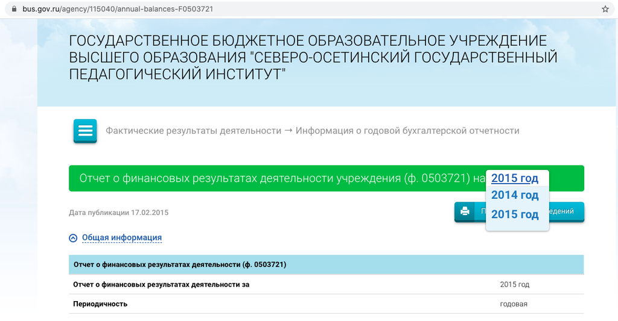

2. У Дагестанского государственного университета народного хозяйства опубликован отчет только за 2017 год (в мониторинег данные есть, см. Таб 2)

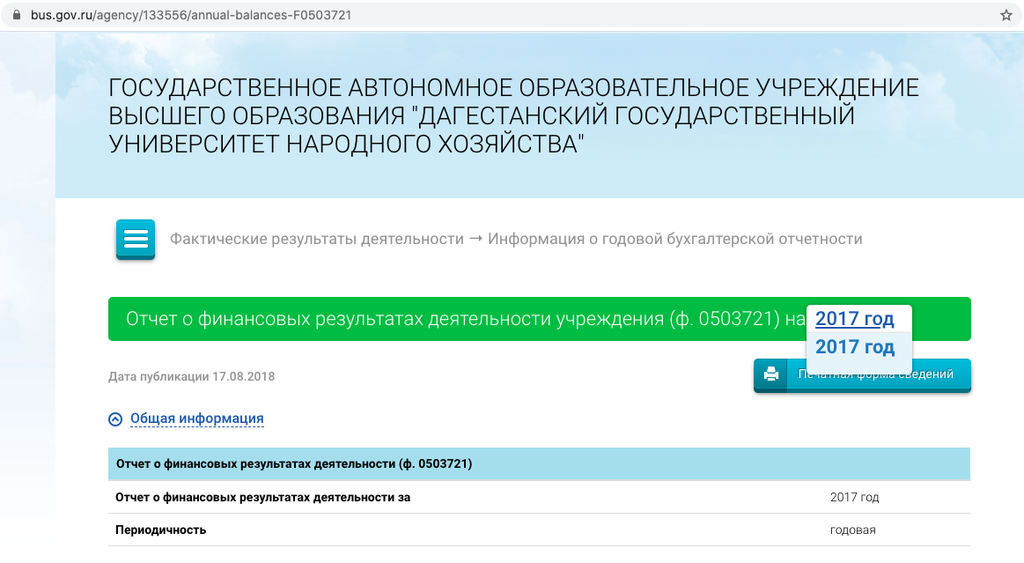

Есть еще одна причина, почему у нас может не оказаться отчета вуза с сайта bus.gov . Мы скачивали отчеты за 2018 год с сайта bus.gov в апреле 2020 года. В нашей выборке есть следующий случай:

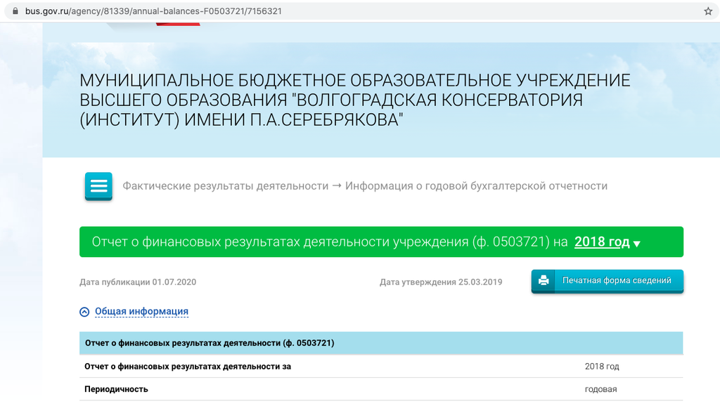

Отчет за 2018 год вроде бы висит на сайте, но есть присмотреться, то видно, что дата его публикации - 01.07.2020. То есть вуз опубликовал отчет с опозданием на пару лет и когда мы в апреле 2020 скачивали отчеты он еще не был вывешен.

# Есть на bus.gov, нет в Мониторинге

Таких вуза всего два. ТОЛЬЯТТИНСКАЯ КОНСЕРВАТОРИЯ и НАБЕРЕЖНОЧЕЛНИНСКИЙ ГОСУДАРСТВЕННЫЙ ТОРГОВО-ТЕХНОЛОГИЧЕСКИЙ ИНСТИТУТ не ищутся в Мониторинге 2019 (это и есть на конец 2018 года), но при этом эти вузы есть на bus.gov.ru и они опубликовали там отчеты. Кроме того, В Мониторинег годом ранее эти вузы есть и данные они предоставляли.

### Таблица 3 (млн руб.)

|  | name_mon_2019 | Monit_on_end_2017 | Monit_on_end_2018 | BusGov_on_end_2018 |
| --- | --- | --- | --- | --- |
| 1 | Государственное автономное образовательное учреждение высшего образования "набережночелнинский государственный торгово-технологический институт" | 85.7479 | NA | 73.15785365 |
| 2 | муниципальное бюджетное образовательное учреждение высшего образования городского округа Тольятти "Тольяттинская консерватория" | 68.179 | NA | 50.94141973 |

# Есть везде, но совпадают ли?

Последовательно делаем следующее:

1. Выкинем 2 вуза, которые есть на bus.gov, но нет в Мониторинге.
2. Выкинем 39 вузов которые есть в Мониторинге, но нет на bus.gov.
3. Выкинем 69 вузов которые есть в Мониторинге, но на bus.gov они подгрузили нудевые отчеты.
4. Посчитаем $diff = \frac{Monit\_on\_end\_2018}{BusGov\_on\_end\_2018}*100$

### Таблица 4 (млн руб.)

|  | short_name | Monit_on_end_2017 | Monit_on_end_2018 | BusGov_on_end_2018 | diff(%) |
| --- | --- | --- | --- | --- | --- |
| 1 | МОСКОВСКИЙ ТЕХНИЧЕСКИЙ УНИВЕРСИТЕТ СВЯЗИ И ИНФОРМАТИКИ | 1322.0148 | 1408.786 | 22.32987987 | 6308.97258830618 |
| 2 | КОМСОМОЛЬСКИЙ-НА-АМУРЕ ГОСУДАРСТВЕННЫЙ УНИВЕРСИТЕТ | 672.3511 | 1016.4027 | 213.78640912 | 475.429052849419 |
| 3 | УРАЛЬСКИЙ ГОСУДАРСТВЕННЫЙ ЮРИДИЧЕСКИЙ УНИВЕРСИТЕТ | 1092.6819 | 1190.5486 | 297.53734747 | 400.134171432055 |
| 4 | СИБИРСКИЙ ГОСУДАРСТВЕННЫЙ ИНСТИТУТ ИСКУССТВ ИМЕНИ ДМИТРИЯ ХВОРОСТОВСКОГО | 277.7013 | 322.6454 | 110.39629308 | 292.261081417101 |
| 5 | ДАГЕСТАНСКИЙ ГОСУДАРСТВЕННЫЙ МЕДИЦИНСКИЙ УНИВЕРСИТЕТ МИНИСТЕРСТВА ЗДРАВООХРАНЕНИЯ РОССИЙСКОЙ ФЕДЕРАЦИИ | 1024.0963 | 1278.4474 | 474.49096569 | 269.435561990289 |
| 6 | СМОЛЕНСКАЯ ГОСУДАРСТВЕННАЯ СЕЛЬСКОХОЗЯЙСТВЕННАЯ АКАДЕМИЯ | 140.5245 | 164.5466 | 77.21589396 | 213.09939127978 |
| 7 | МОРСКОЙ ГОСУДАРСТВЕННЫЙ УНИВЕРСИТЕТ ИМЕНИ АДМИРАЛА Г.И. НЕВЕЛЬСКОГО | 1975.5076 | 2935.7031 | 1436.96226358 | 204.299248101762 |
| 8 | ГРОЗНЕНСКИЙ ГОСУДАРСТВЕННЫЙ НЕФТЯНОЙ ТЕХНИЧЕСКИЙ УНИВЕРСИТЕТ ИМЕНИ АКАДЕМИКА М. Д. МИЛЛИОНЩИКОВА | 670.4325 | 973.0992 | 578.29883926 | 168.269263906044 |
| 9 | БРЯНСКИЙ ГОСУДАРСТВЕННЫЙ АГРАРНЫЙ УНИВЕРСИТЕТ | 438.0623 | 523.8643 | 312.58966207 | 167.588491740552 |
| 10 | УРАЛЬСКИЙ ГОСУДАРСТВЕННЫЙ ПЕДАГОГИЧЕСКИЙ УНИВЕРСИТЕТ | 869.2589 | 917.8945 | 549.57107093 | 167.020163278739 |

[output cut: 381 more lines]

В таб. 4 мы сразу видим аномалии. МОСКОВСКИЙ ТЕХНИЧЕСКИЙ УНИВЕРСИТЕТ СВЯЗИ И ИНФОРМАТИКИ в Мониторинге за 2018 год заявил доходы 1408 руб. При этом на bus.gov вуз заявил доходы за 2018 год 22 млн. руб. Так как мы видим, что данные в Мониторинге более реалистичны и последовательны (смотрим что вуз заявлял в 2017 в Мониторинге), то проверим в чем может быть причина на сайте bus.gov. Смотрим оригинальный отчет вуза на bus.gov:

##### Отчеты МОСКОВСКОГО ТЕХНИЧЕСКОГО УНИВЕРСИТЕТА СВЯЗИ И ИНФОРМАТИКИ с bus.gov

###### 2018

[interactive chart not shown]

###### 2017

[interactive chart not shown]

Мы смотрим на сторчку 010 100 столбец Итого. В 2018 году действительно заявлено 22 млн. При этом в 2017 заявлено 1372 млн. - а это уже очень похоже на данные Мониторинга. Короче посчитаем это какой-то аномалией с которой мы сможем разобраться только если позвоним в бухгалтерию этого вуза. Уберем его из выборки и посмотрим на обзее распределение всех вузов из Табл. 4.

### Рис 1

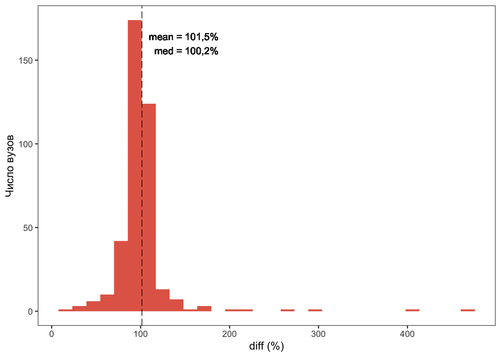

Мы видим, что в среднем данные в мониторинге соответстветствуют данным на bus.gov, но это только в среднем. Все вузы, что у нас на графике левее 100, это вузы которые заявили на сайте bus.gov доходы выше, чем в мониторинге. Например, см. табл.4 отсортированную по *diff* в порядке возрастнания. ВСЕРОССИЙСКИЙ ГОСУДАРСТВЕННЫЙ УНИВЕРСИТЕТ ЮСТИЦИИ на bus.gov заявил доход 2047 млн. а в мониторинге только 23% от этой суммы - 474 млн. Сортируем табл.4 *diff* в порядке убывания и видим КОМСОМОЛЬСКИЙ-НА-АМУРЕ ГОСУДАРСТВЕННЫЙ УНИВЕРСИТЕТ, который в Мониторинге заявил доход 1016 млн. и это 475% заявленной на bus.gov суммы - на bus.gov заявлено 213 млн доходов.

# Вывод

| X1 | Мониторинг | bus.gov.ru |
| --- | --- | --- |
| Число вузов с данными о доходах | 499 | 462 |
| из них фиктивных данных | 0 | 69 нулевых отчетов |
| Итого вузов с адекватными данными | 499 | 393 |